# HW7

Mike Ament

March 10, 2020

# 1) Go back to your “thinking on paper” exercise, and decide on a pattern that you might expect in your experiment if a specific hypothesis were true.

Experiment: Plant responses to elevated CO2. Treatment 1 is ambient CO2 conditions and Treatment 2 is elevated CO2 conditions

2. To start simply, assume that the data in each of your treatment groups follow a normal distribution. Specify the sample sizes, means, and variances for each group that would be reasonable if your hypothesis were true.

3. Using the methods we have covered in class, write code to create a random data set that has these attributes. Organize these data into a data frame or tibble with the appropriate structure.

```r
treats<- c("ambient", "elevated")  # treatment groups
n<- c(20, 20)   # sample sizes
mean<- c(50, 60)  ## effect size 20%
sd<- c(10, 10) ## SD same as effect size
plant_wt<- c(rnorm(n=n[1], mean=mean[1], sd=sd[1]),
         rnorm(n=n[2], mean=mean[2], sd=sd[2]))

ID<- 1:length(plant_wt)
treatment<- rep(treats, n) ## interesting, this takes treats and repeats it the number of times of n, which is 20, then 20. These need to have the same dimensions though, I believe, otherwise it will just start over.

data<- data.frame(ID, treatment, plant_wt)

AOVmodel<- aov(plant_wt~treatment, data=data)
summary(AOVmodel)
```

```
##             Df Sum Sq Mean Sq F value   Pr(>F)
## treatment    1   1242  1242.3      16 0.000282 ***
## Residuals   38   2950    77.6
## ---
## Signif. codes:  0 '***' 0.001 '**' 0.01 '*' 0.05 '.' 0.1 ' ' 1
```

4. Now write code to analyze the data (probably as an ANOVA or regression analysis, but possibly as a logistic regression or contingency table analysis. Write code to generate a useful graph of the data.

```r
AOVmodel<- aov(plant_wt~treatment, data=data)
summary(AOVmodel)
```

```
##             Df Sum Sq Mean Sq F value   Pr(>F)
## treatment    1   1242  1242.3      16 0.000282 ***
## Residuals   38   2950    77.6
## ---
## Signif. codes:  0 '***' 0.001 '**' 0.01 '*' 0.05 '.' 0.1 ' ' 1
```

```r
z<- summary(AOVmodel)
unlist(z)
```

```
##          Df1          Df2      Sum Sq1      Sum Sq2     Mean Sq1     Mean Sq2
## 1.000000e+00 3.800000e+01 1.242337e+03 2.949671e+03 1.242337e+03 7.762293e+01
##     F value1     F value2      Pr(>F)1      Pr(>F)2
## 1.600477e+01           NA 2.818919e-04           NA
```

```r
AOVsummary<- list(f=unlist(z)[7], p=unlist(z)[9])
AOVsummary
```

```
## $f
## F value1
## 16.00477
##
## $p
##      Pr(>F)1
## 0.0002818919
```

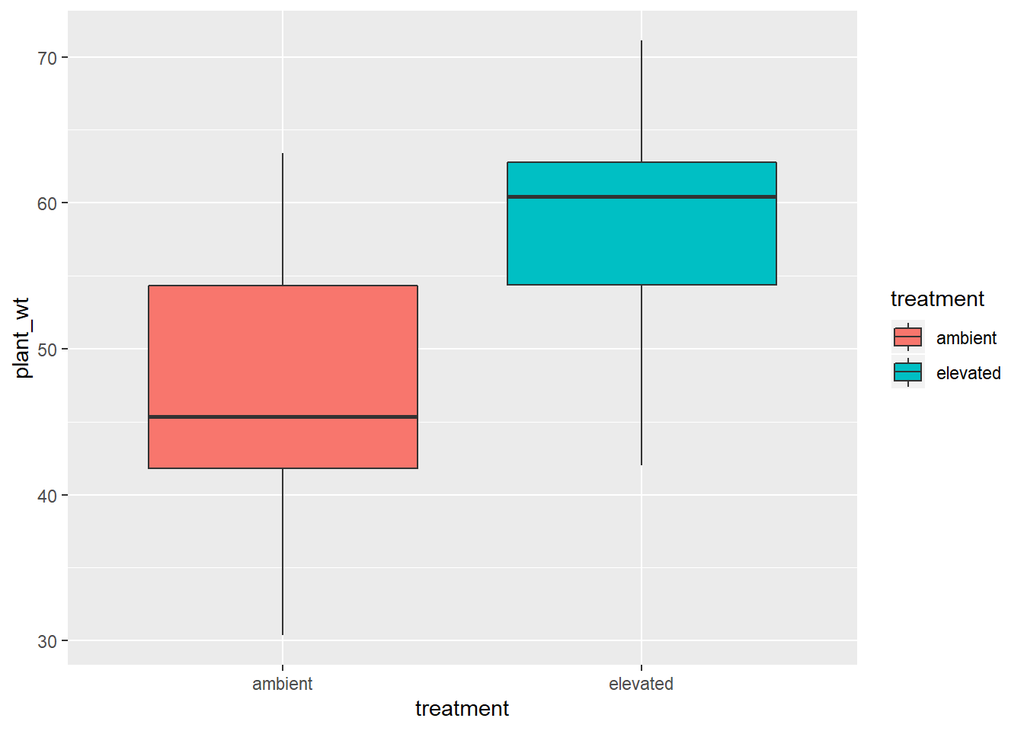

```r
library(ggplot2)
AOVplot<- ggplot(data=data, aes(x=treatment, y=plant_wt, fill=treatment))+
  geom_boxplot()
print(AOVplot)
```

5. Try running your analysis multiple times to get a feeling for how variable the results are with the same parameters, but different sets of random numbers.

Answer: Running my analysis multiple times yeilds slightly different results, but not enough to generate a p-value greater than .05, given the original parameters.

6. Now begin adjusting the means of the different groups. Given the sample sizes you have chosen, how small can the differences between the groups be (the “effect size”) for you to still detect a significant pattern (p < 0.05)?

```r
treats<- c("ambient", "elevated")  # treatment groups
n<- c(20, 20)   # sample sizes
mean<- c(50, 57.5)  ## effect size 10%
sd<- c(10, 10) ## SD same as effect size
plant_wt<- c(rnorm(n=n[1], mean=mean[1], sd=sd[1]),
         rnorm(n=n[2], mean=mean[2], sd=sd[2]))

ID<- 1:length(plant_wt)
treatment<- rep(treats, n)

data<- data.frame(ID, treatment, plant_wt)

AOVmodel<- aov(plant_wt~treatment, data=data)
summary(AOVmodel)
```

```
##             Df Sum Sq Mean Sq F value   Pr(>F)
## treatment    1   1567    1567   15.22 0.000378 ***
## Residuals   38   3914     103
## ---
## Signif. codes:  0 '***' 0.001 '**' 0.01 '*' 0.05 '.' 0.1 ' ' 1
```

Answer: My orginal effect size was 20% (or 10 grams) and 10/10 simulations yielded a significant results (p<.05). Changing my effect size to 10% (or 5 grams) though, yielded a significant p value only 2/10 times. I then increased the effect size to 15% (7.5g) and saw a significant p value 5/10 times. Therefore, an effect size of about 17% is about the smallest I need to consistently detect a difference between the treatment groups (given a sample size of 20 and a standard deviation of 10g).

7. Alternatively, for the effect sizes you originally hypothesized, what is the minimum sample size you would need in order to detect a statistically significant effect? Again, run the model a few times with the same parameter set to get a feeling for the effect of random variation in the data.

```r
treats<- c("ambient", "elevated")  # treatment groups
n<- c(10, 10)   # sample sizes
mean<- c(50, 60)  ## effect size 20%
sd<- c(10, 10) ## SD same as effect size
plant_wt<- c(rnorm(n=n[1], mean=mean[1], sd=sd[1]),
         rnorm(n=n[2], mean=mean[2], sd=sd[2]))

ID<- 1:length(plant_wt)
treatment<- rep(treats, n)

data<- data.frame(ID, treatment, plant_wt)

AOVmodel<- aov(plant_wt~treatment, data=data)
summary(AOVmodel)
```

```
##             Df Sum Sq Mean Sq F value Pr(>F)
## treatment    1  194.4  194.38   4.737 0.0431 *
## Residuals   18  738.7   41.04
## ---
## Signif. codes:  0 '***' 0.001 '**' 0.01 '*' 0.05 '.' 0.1 ' ' 1
```

Dropping my sample size from 15 to 20 produced a 30% increase in the number of times I observed as statistically insignificant p value. Dropping it from 15 to 10 produced a 50% increase in the number of times in the number of statistically insignificant results.

8. Write up your results in a markdown file, organized with headers and different code chunks to show your analysis. Be explicit in your explanation and justification for sample sizes, means, and variances.